# Notes on benchmarking several coil design codes (NESCOIL, REGCOIL, COILOPT++, FOCUS)

By Caoxiang Zhu

Generally, coil design codes optimize external currents to reproduce the target magnetic field. Currently, the four popular codes, **NESCOIL, REGCOIL, COILOPT++** and **FOCUS**, are all trying to fit a given Bn distribution on a given toroidal boundary, despite the difference on solving the current potential or coil filaments and the optimization algorithms they used. Thus, the information of plasma currents is needed as a input and this is provided by the code **BNORM**. These five codes are developed independently and each code has its own numerical conventions. We checked the details in each code and benchmark the codes with one particular case.

For your convenience, you could just have a quick view at the Summary.

- BNORM
  - Plasma boundary representation
  - Normal vector of plasma boundary
  - Bn convention
  - Normalization factor
  - Comments
- NESCOIL
  - Plasma boundary representation
  - Normal vector of plasma boundary
  - Bn convention
  - Normalization factor
  - Total magnetic field
  - Comments
- REGCOIL
  - Plasma boundary representation
  - Normal vector of plasma boundary
  - Bn convention
  - Normalization factor
  - Total magnetic field
  - Comments
- COILOPT++
  - Plasma boundary representation
  - Normal vector of plasma boundary
  - Bn convention
  - Normalization factor
  - Total magnetic field
  - Comments
- FOCUS
  - Plasma boundary representation
  - Normal vector of plasma boundary
  - Bn convention
  - Normalization factor
  - Total magnetic field
  - Comments
- Summary
- Appendix A: Numerical verifications among NESCOIL, REGCOIL and FOCUS
  - Equilibrium
  - BNORM results
  - NESCOIL results
  - REGCOIL results
  - Benchmark between NESCOIL and REGCOIL
  - Free-boundary VMEC results
  - FOCUS results
- Appendix B: A simple verification of FOCUS
- Questions

## BNORM

### Plasma boundary representation

Although **BNORM** reads **VMEC** outputs, it uses *(mu+nv)* convention for representing the surface, where *u* and *v* are normalized poloidal and toroidal angle. Therefore, it flips the sign of *n* when reading **VMEC** coefficients. Here is the snippet of code from *bn_read_vmecf90.f*.

```
do mn = 1, mnmax
     ixm(mn) = nint(xm(mn))
     ixn(mn) =-nint(xn(mn))/nfp   !!Flip sign: NESCOIL convention
     m = ixm(mn)
     n = ixn(mn)
     bsubu(m,n) = 1.5_dp*bsubumnc(mn,ns) - 0.5_dp*bsubumnc(mn,ns-1)
     bsubv(m,n) = 1.5_dp*bsubvmnc(mn,ns) - 0.5_dp*bsubvmnc(mn,ns-1)
     cl(m,n) = 1.5_dp*lmns(mn,ns) - 0.5_dp*lmns(mn,ns-1)
     cr(m,n) = rmnc(mn,ns)
     cz(m,n) = zmns(mn,ns)
  end do
```

### Normal vector of plasma boundary

To calculate the normal magnetic field on plasma boundary, it is essential to compute the normal vector of the surface. In **BNORM**, the normal vector $\bf N = X_u \times X_v$, where $\bf X_u$ and $\bf X_v$ are the derivatives with respect to angles. This part can be found in *bn_surface.f*.

```
do   i = 1 , nuv
     snx    = yu(i)*zv(i)-zu(i)*yv(i)
     sny    = zu(i)*xv(i)-xu(i)*zv(i)
     snz    = xu(i)*yv(i)-yu(i)*xv(i)
     sqf(i) = sqrt(snx*snx+sny*sny+snz*snz)
     guu(i) = xu(i)*xu(i)+yu(i)*yu(i)+zu(i)*zu(i)
     guv(i) = xu(i)*xv(i)+yu(i)*yv(i)+zu(i)*zv(i)
     gvv(i) = xv(i)*xv(i)+yv(i)*yv(i)+zv(i)*zv(i)
     dju(i) = bu(i)*guv(i)- bv(i)*guu(i)
     djv(i) = bu(i)*gvv(i)- bv(i)*guv(i)
  enddo
```

### Bn convention

**BNORM** takes a Fourier transformation over the normal field and calculates the Fourier coefficients. It represents the normal field as $B_n = \sum_m \sum_n bns_{m,n} \sin(mu+nv)$. This part can be found in *bn_fouri.f*

```
do  m  = 0,mf
     faz   = 2*fnuv
     if(m.eq.0) faz = fnuv
     do  n  = -nf,nf
        bnfou(m,n) = 0
        bnfou_c(m,n) = 0
        do  i = 1,nuv
           cofp   = conu(i,m)*conv(i,n)-sinu(i,m)*sinv(i,n)         !cos(u+v)
           sifp   = sinu(i,m)*conv(i,n)+conu(i,m)*sinv(i,n)         !sin(u+v)
           bnfou(m,n) = bnfou(m,n) +bn(i)/sqf(i)*sifp*faz
!          bnfou_c(m,n)=bnfou_c(m,n) +bn(i)/sqf(i)*cofp*faz
        enddo
     enddo
  enddo
```

### Normalization factor

**BNORM** results are normalized so that the poloidal current per period, $I_p$, is one. This is found in *bnormal.f*.

```
!----------------------------------------------------------------------
c                                                          15.08.98
c    purpose:
c

c    compuce
c                   /
c               1   |   [ j', x-x'] . n
c     B.n   =  ---- |  ----------------- df ,  x,x' on the boundary
c              4 pi |     |x-x'|^(3/2)
c                   /
c
c
c       j   = B_subu . xv - B_subv . xu
c
c the result ist normalized so that the toroidal integral
c
c              /
c              |
c     I_p  =   |  B. ds  per field period   is I_p  =1.
c              |
c              /
c ----------------------------------------------------------------------
```

And also in *bn_parallel.f* and *bn_read_vmecf90.f*.

```
m = ixm(mn)
     n = ixn(mn)
     bsubu(m,n) = 1.5_dp*bsubumnc(mn,ns) - 0.5_dp*bsubumnc(mn,ns-1)
     bsubv(m,n) = 1.5_dp*bsubvmnc(mn,ns) - 0.5_dp*bsubvmnc(mn,ns-1)


      curpol = alp*bsubv(0,0) ! alp=pi2/np
      do m=  0,md
         do n=-nd,nd
            bsubu(m,n) = pi2*bsubu(m,n)/curpol
            bsubv(m,n) = alp*bsubv(m,n)/curpol
            bsubus(m,n) = pi2*bsubus(m,n)/curpol
            bsubvs(m,n) = alp*bsubvs(m,n)/curpol
         enddo
      enddo
```

### Comments

In the above code comments, **BNORM** is calculating the interior normal field. In the code documentation ([link](https://princetonuniversity.github.io/STELLOPT/docs/bnorm_prog_notes.pdf)), eq. 1 is indicating interior while eq. 12 is exterior. Based on FOCUS test, **BNORM** is calculating the **interior** normal field.

## NESCOIL

[**NESCOIL**](https://dx.doi.org/10.1088/0029-5515/27/5/018) solves current potential on a given current-carrying-surface to produce the target magnetic field.

### Plasma boundary representation

**NESCOIL** reads boundary coefficients from *nescin.xxx* file, which is generally prepared by **BNORM**. It uses the plus convention for representing the boundary. This could be found in the original paper and in the source code *surface_plas.f*.

```
do 20 m = 0,ms1
  do 20 n = 0,ns1
     cm     = m*pi2
     cn     = n*pi2
     i      = 0
  do 20 kv = 1 , nv1/2 + 1
  do 20 ku = 1 , nu1
     i      = i + 1
     cofp   = comu1(ku,m)*conv1(kv,n)-simu1(ku,m)*sinv1(kv,n)
     cofm   = comu1(ku,m)*conv1(kv,n)+simu1(ku,m)*sinv1(kv,n)
     sifp   = simu1(ku,m)*conv1(kv,n)+comu1(ku,m)*sinv1(kv,n)
     sifm   = simu1(ku,m)*conv1(kv,n)-comu1(ku,m)*sinv1(kv,n)
     r1(i)   = r1(i)    +       cr1(m,n)*cofp + cr1(m,-n)*cofm
     z1(i)   = z1(i)    +       cz1(m,n)*sifp + cz1(m,-n)*sifm
     r1u(i)  = r1u(i)   - cm *( cr1(m,n)*sifp + cr1(m,-n)*sifm )
     y1v(i)  = y1v(i)   - cn *( cr1(m,n)*sifp - cr1(m,-n)*sifm )
     z1u(i)  = z1u(i)   + cm *( cz1(m,n)*cofp + cz1(m,-n)*cofm )
     z1v(i)  = z1v(i)   + cn *( cz1(m,n)*cofp - cz1(m,-n)*cofm )
     r1uu(i) = r1uu(i) -cm*cm*( cr1(m,n)*cofp + cr1(m,-n)*cofm )
     z1uu(i) = z1uu(i) -cm*cm*( cz1(m,n)*sifp + cz1(m,-n)*sifm )
20 continue
```

### Normal vector of plasma boundary

In **NESCOIL**, the normal vector $\bf N = X_u \times X_v$, where $\bf X_u$ and $\bf X_v$ are the derivatives with respect to angles. This part can be found in *surface_plas.f*.

```
snx1(i) = y1u(i)*z1v(i) - z1u(i)*y1v(i)
sny1(i) = z1u(i)*x1v(i) - x1u(i)*z1v(i)
snz1(i) = x1u(i)*y1v(i) - y1u(i)*x1v(i)
! snx1, sny1, snz1 are later normalized to |N|
```

### Bn convention

**NESCOIL** reads *bnorm.xxx* file to get the Bn information on the boundary. As **BNORM**, it uses plus sign to compute the Bn on grids from Fourier coefficients. However, it has a factor, $-4\pi$, multiplied to Bn. It comes from $\mu_0/4\pi$, but $\mu_0$ has already been taken out in **VMEC**. This can be found in *bnfld.f*.

```
! Turn bnorm_mn into bn_ext(nuvh1) on plasma surface
  bnorm_mn(:ms,0) = .5*bnorm_mn(:ms,0)
  do m = 0, ms
     do n = 0, ns
!           cm = m*pi2
!           cn = n*pi2
        i = 0
        do  kv = 1 , nv1/2 + 1
           do  ku = 1 , nu1
              i  = i + 1
              sifp = simu(ku,m)*conv(kv,n)+comu(ku,m)*sinv(kv,n)
              sifm = simu(ku,m)*conv(kv,n)-comu(ku,m)*sinv(kv,n)
              bn_ext(i) = bn_ext(i) + bnorm_mn(m,n)*sifp
 1                                  + bnorm_mn(m,-n)*sifm
           end do
        end do
     end do
  end do
!
  if (iloop .le. 0) deallocate (bnorm_mn)

  fact = -2*pi2
  bn_ext(:nuvh1) = fact*bn_ext(:nuvh1)
```

### Normalization

Although **NESCOIL** reads *curpol* in *nescin.xxx*, it doesn't use it and the parameters that determines the poloidal and toroidal current are *cup* and *cup*. Since **BNORM** has already normalized the Bn coefficients to let *cup=1.0*, there is no extra normalizations in **NESCOIL**. Of course, you could still provide cutomized *cup* and *cut*.

### Total magnetic field

After calculating the magnetic field from plasma, **NESCOIL** will add it the normal field produced by the total current potential, just as shown in *accuracy.f*.

```
call besurfcur(spx, spy, spz)
 berr = snx1(i)*bx+sny1(i)*by+snz1(i)*bz + bn_ext(i)
```

### Comments

1. It's strange that in the code **NESCOIL** uses opposite normal vector as it desicribes in the paper.
2. *bn_ext* is multiplied by a factor of $-4\pi$ and this changes the sign of bn_ext. This is understandable if **BNORM** is calculating exterior normal component and **NESCOIL** uses interior normal vector. As to $4\pi$, I think it's from the constant $\mu_0 / 4\pi$ in Biot-Savart Law, while $\mu_0$ is taken out.

## REGCOIL

[**REGCOIL**](https://dx.doi.org/10.1088/1741-4326/aa57d4) solves current potential on a given current-carrying-surface to produce the target magnetic field, regularized to the total current density.

### Plasma boundary representation

After reading boundary coefficients, **REGCOIL** uses the minus convention for representing the boundary, the same as **VMEC**. This could be found in the original paper and in the source code *regcoil_init_plasma_mod.f90*.

```
do izeta = 1,nzetal_plasma
   angle2 = zetal_plasma(izeta)
   sinangle2 = sin(angle2)
   cosangle2 = cos(angle2)
   dsinangle2dzeta = cosangle2
   dcosangle2dzeta = -sinangle2
   do itheta = 1,ntheta_plasma
      do imn = 1,mnmax_plasma
         angle = xm_plasma(imn)*theta_plasma(itheta) - xn_plasma(imn)*zetal_plasma(izeta) ! minus convention
         sinangle = sin(angle)
         cosangle = cos(angle)
         dsinangledtheta = cosangle*xm_plasma(imn)
         dcosangledtheta = -sinangle*xm_plasma(imn)
         dsinangledzeta = -cosangle*xn_plasma(imn)
         dcosangledzeta = sinangle*xn_plasma(imn)

         r_plasma(1,itheta,izeta) = r_plasma(1,itheta,izeta) + rmnc_plasma(imn) * cosangle * cosangle2
         r_plasma(2,itheta,izeta) = r_plasma(2,itheta,izeta) + rmnc_plasma(imn) * cosangle * sinangle2
         r_plasma(3,itheta,izeta) = r_plasma(3,itheta,izeta) + zmns_plasma(imn) * sinangle

         ...

      end do
   end do
end do
```

### Normal vector of plasma boundary

In **REGCOIL**, the normal vector is computed as $\bf N = X_{\zeta} \times X_{\theta}$, where $\bf X_{\theta}$ and $\bf X_{\zeta}$ are the derivatives with respect to angles. This part can be found in *regcoil_init_plasma_mod.f90*.

```
! Evaluate cross product
normal_plasma(1,:,:) = drdzeta_plasma(2,:,:) * drdtheta_plasma(3,:,:) - drdtheta_plasma(2,:,:) * drdzeta_plasma(3,:,:)
normal_plasma(2,:,:) = drdzeta_plasma(3,:,:) * drdtheta_plasma(1,:,:) - drdtheta_plasma(3,:,:) * drdzeta_plasma(1,:,:)
normal_plasma(3,:,:) = drdzeta_plasma(1,:,:) * drdtheta_plasma(2,:,:) - drdtheta_plasma(1,:,:) * drdzeta_plasma(2,:,:)
```

### Bn convention

**REGCOIL** reads *bnorm.xxx* file to get the Bn information on the boundary. As **BNORM**, it uses plus sign to compute the Bn on grids from Fourier coefficients. It will multiply a factor of *curpol* to Bn. This can be found in *regcoil_init_bnorm.f90*.

```
num_modes_added = 0
do
 read(iunit,*,iostat = i) mm, nn, bf
 if (i .ne. 0) exit
 num_modes_added = num_modes_added+1
 !print *,"  Adding a mode with m=",mm,",  n=",nn
 do izeta = 1,nzeta_plasma
    do itheta = 1,ntheta_plasma
       Bnormal_from_plasma_current(itheta,izeta) = Bnormal_from_plasma_current(itheta,izeta) + &
            bf*sin(mm*theta_plasma(itheta) + nn*nfp*zeta_plasma(izeta))

       ! To see that it should be (mu+nv) rather than (mu-nv) in the above line, you can examine
       ! BNORM/Sources/bn_fouri.f (where the arrays in the bnorm files are computed)
       ! or
       ! either NESCOIL/Sources/bnfld.f (where bnorm files are read)
    end do
 end do
end do

close(iunit)

! BNORM scales B_n by curpol=(2*pi/nfp)*bsubv(m=0,n=0)
! where bsubv is the extrapolation to the last full mesh point of
! bsubvmnc.  Let's undo this scaling now.
Bnormal_from_plasma_current = Bnormal_from_plasma_current * curpol
```

### Normalization

In **REGCOIL** , the Bn coefficients are multiplied by *curpol*, which is obtained from reading **VMEC** outputs.

### Total magnetic field

The net coil currents, i.e. secular poloidal and toroidal currents from external coils, are also read in the unit of *Amper*. The produced magnetic field is calculated and stored in *Bnormal_from_net_coil_currents*. The total magnetic field is the sum of each field, as shown in *regcoil_diagnostics.f90*.

```
Bnormal_total(:,:,ilambda) = (reshape(matmul(g,solution),(/ ntheta_plasma, nzeta_plasma /)) / norm_normal_plasma) &
   + Bnormal_from_plasma_current + Bnormal_from_net_coil_currents
```

### Comments

There are two main differences between **NESCOIL** and **REGCOIL** that might cause problems.

1. The normal vectors are in opposite directions.
2. **NESCOIL** doesn't use SI units ($\mu_0$ is out), while **REGCOIL** does.

## COILOPT++

[**COILOPT++**](https://princetonuniversity.github.io/STELLOPT/COILOPT) code calculates coil filaments on a given winding surface using B-spline representation.

### Plasma boundary representation

After reading boundary coefficients, **COILOPT++** uses the plus convention for representing both the plasma boundary and the winding surface. Thus, it flips the sign of *n*. This could be found in the source code *toroidalSurface.C*.

```
// In readVMECcdf.C
// Rectify toroidal mode numbers (VMEC series is in terms of -phi, not +v).
for (int imode=0; imode<nmodes; imode++) {
  assert(nnum[imode] % nfper == 0);
  nnum[imode] /= -nfper;
}
/////////////////////////////////////
// Parametric surface evaluator (cylindrical)
// void vmecSurface::uv2Rz(const real u, const real v, real& R, real& z) const
// {
//   real arg;
//
//   R = z = 0.0;
//   for (int mode=0; mode<nmodes; mode++) {
//     arg = twopi*(mnum[mode]*u + nnum[mode]*v);
//     R += rmn[mode] * cos(arg);
//     z += zmn[mode] * sin(arg);
//   }
// }
```

### Normal vector of plasma boundary

In **COILOPT++**, the normal vector $\bf N = X_v \times X_u$, where $\bf X_u$ and $\bf X_v$ are the derivatives with respect to angles. This part can be found in *toroidalSurface.C*.

```
////////////////////////////////////////////////////////////////////////
// Parametric surface evaluator with derivatives (Cartesian)
vector vmecSurface::uv2xyzprime(const real u, const real v,
                vector prime[5])
  const
{
  real R[6], z[6], phi, cp, sp;

  uv2Rzprime(u, v, R, z); //1st get derivs of cylindrical coords

  phi = dphidv * v;
  cp = cos(phi);  sp = sin(phi);

  vector x0(R[0]*cp, R[0]*sp, z[0]);                            // x, y, z
  prime[0] = vector(R[1]*cp, R[1]*sp, z[1]);                    // d/du
  prime[1] = vector(R[2]*cp - dphidv*x0.y,
            R[2]*sp + dphidv*x0.x, z[2]);               // d/dv
  prime[2] = vector(R[3]*cp, R[3]*sp, z[3]);                    // d2/du2
  prime[3] = vector(R[4]*cp - dphidv*prime[0].y,
            R[4]*sp + dphidv*prime[0].x, z[4]);         // d2/dudv
  prime[4] = vector(R[5]*cp - dphidv*(2.0*R[2]*sp + dphidv*x0.x),
            R[5]*sp + dphidv*(2.0*R[2]*cp - dphidv*x0.y),
            z[5]);                                      //d2/dv2

  return x0;
}

////////////////////////////////////////////////////////////////
// Normal calculator
vector vmecSurface::unitnormal(const real u, const real v) const
{
  vector prime[5];

  uv2xyzprime(u, v, prime);
  vector normal = prime[1] * prime[0];
  real len = normal.mag();
  assert(len > 0.0);
  return normal/len;
}
```

### Bn convention

**COILOPT++** reads bnorm.xxx file to get the Bn information on the boundary. As **BNORM**, it uses plus sign to compute the Bn on grids from Fourier coefficients. It will multiply a factor of curpol to Bn. This can be found in *plasma.C*.

```
// Read data, scale to VMEC poloidal current value.
  rewind(fp);
  for (int imode=0; imode<numBcoefs; imode++) {
fscanf(fp, "%d %d %le", mnum+imode, nnum+imode, bnormcoef+imode);
bnormcoef[imode] *= curpol_vmec;
  }
```

### Normalization factor

In **COILOPT++** , the Bn coefficients are multiplied by *curpol*, which is obtained from reading **VMEC** outputs.

### Total magnetic field

**COILOPT++** calculates the total magnetic field and add the normal field to Bn_plasma, as shown in *plasma.C*.

```
vector Bcoils(0.0), sp(surfpos[impt]);

// Contributions from varying-geometry coils
for (int iws=0; iws<nws; iws++)
  for (int iloop=0; iloop<nloops[iws]; iloop++)
Bcoils += loop[iws][iloop]->Bfield_T(sp);

// Contributions from fixed-geometry coils
for (int ifix=0; ifix<nfixed; ifix++)
  Bcoils += fixedcurrent[ifix][0] * B_fixed[ifix][impt];

// Contribution from background TF
if (settings.bgtfR0B0 != 0.0)
  Bcoils += ((settings.bgtfR0B0/(sp.x*sp.x + sp.y*sp.y)) *
     vector(-sp.y, sp.x, 0.0));

// Contribution from background VF
Bcoils.z += bgBz;

real dBoB = bnorm[impt] + (Bcoils % nhat[impt]);
```

### Comments

**COILOPT++** uses **NESCOIL** convention on plasma boundary, but flips the direction of normal vector.

## FOCUS

[**FOCUS**](https://dx.doi.org/10.1088/1361-6587/aab8c2) nonlinearly optimizes coil filaments using 3D representation.

### Plasma boundary representation

After reading boundary coefficients, **FOCUS** uses the minus convention for representing the boundary, the same as **VMEC**. This could be found in the original paper and in the source code *rdsurf.h*.

```
! The center point value was used to discretize grid;
  do ii = 0, Nteta-1; teta = ( ii + half ) * pi2 / Nteta
     do jj = 0, Nzeta-1; zeta = ( jj + half ) * pi2 / ( Nzeta*Nfp )

     RR(0:2) = zero ; ZZ(0:2) = zero

     do imn = 1, Nfou ; arg = bim(imn) * teta - bin(imn) * zeta  ! mu-nv

        RR(0) =  RR(0) +     Rbc(imn) * cos(arg) + Rbs(imn) * sin(arg)
        ZZ(0) =  ZZ(0) +     Zbc(imn) * cos(arg) + Zbs(imn) * sin(arg)

        RR(1) =  RR(1) + ( - Rbc(imn) * sin(arg) + Rbs(imn) * cos(arg) ) * bim(imn)
        ZZ(1) =  ZZ(1) + ( - Zbc(imn) * sin(arg) + Zbs(imn) * cos(arg) ) * bim(imn)

        RR(2) =  RR(2) - ( - Rbc(imn) * sin(arg) + Rbs(imn) * cos(arg) ) * bin(imn)
        ZZ(2) =  ZZ(2) - ( - Zbc(imn) * sin(arg) + Zbs(imn) * cos(arg) ) * bin(imn)

        ...

      end do
   end do
end do
```

### Normal vector of plasma boundary

In **FOCUS**, the normal vector is computed as $\bf N = X_{\zeta} \times X_{\theta}$, where $\bf X_{\theta}$ and $\bf X_{\zeta}$ are the derivatives with respect to angles. This part can be found in *rdsurf.h*.

```
xx(1:3) = (/   RR(0) * czeta,   RR(0) * szeta, ZZ(0) /)  ! x, y, z
xt(1:3) = (/   RR(1) * czeta,   RR(1) * szeta, ZZ(1) /)  ! dx/dtheta
xz(1:3) = (/   RR(2) * czeta,   RR(2) * szeta, ZZ(2) /) + (/ - RR(0) * szeta,   RR(0) * czeta, zero  /) ! dx/dzeta

ds(1:3) = -(/ xt(2) * xz(3) - xt(3) * xz(2), & ! minus sign for theta counterclockwise direction;
              xt(3) * xz(1) - xt(1) * xz(3), &
              xt(1) * xz(2) - xt(2) * xz(1) /)

dd = sqrt( sum( ds(1:3)*ds(1:3) ) )

! x, y, z coordinates for the surface;
surf(1)%xx(ii,jj) = xx(1)
surf(1)%yy(ii,jj) = xx(2)
surf(1)%zz(ii,jj) = xx(3)

! dx/dt, dy/dt, dz/dt (dt for d theta)
surf(1)%xt(ii,jj) = xt(1)
surf(1)%yt(ii,jj) = xt(2)
surf(1)%zt(ii,jj) = xt(3)

! surface normal vectors and ds for the jacobian;
surf(1)%nx(ii,jj) = ds(1) / dd
surf(1)%ny(ii,jj) = ds(2) / dd
surf(1)%nz(ii,jj) = ds(3) / dd
surf(1)%ds(ii,jj) =         dd
```

### Bn convention

**FOCUS** reads Bn coefficients to get the Bn information on the boundary. Unlike **BNORM**, it uses minus sign to compute the Bn on grids from Fourier coefficients. It will multiply a factor of *curpol* to Bn. This can be found in *vmec2focus.py* and *rdsurf.h*.

```
...

curpol = 2.0*np.pi / Nfp * wout['rbtor'].values  # not rbtor0, it's rbtor

...

for imn in range(Nbnf):
    fofile.write("{:d} \t {:d} \t {:23.15E} \t {:23.15E} \n".format(-bn[imn], bm[imn], 0.0, bns[imn]))
    # negative n, because FOCUS and BNORM are taking different rep.
...
```

```
!calculate target Bn with input harmonics; 05 Jan 17;
if(NBnf >  0) then

 do jj = 0, Nzeta-1 ; zeta = ( jj + half ) * pi2 / (Nzeta*Nfp)
    do ii = 0, Nteta-1 ; teta = ( ii + half ) * pi2 / Nteta
       do imn = 1, NBnf
          arg = Bnim(imn) * teta - Bnin(imn) * zeta
          surf(1)%pb(ii,jj) = surf(1)%pb(ii,jj) + Bnc(imn)*cos(arg) + Bns(imn)*sin(arg)
       enddo
    enddo
 enddo

endif
```

### Normalization

Inside **FOCUS**, there is no normalization on Bn. But you have to pay attention to providing the correct Bn.

### Total magnetic field

**FOCUS** reads all the other magnetic field except the coils to be solved and treats them as the target boundary condition. Therefore, the total magnetic field is obtained by subtraction, as shown in *bnormal.h*.

```
lbn(iteta, jzeta) = lbx(iteta, jzeta)*surf(1)%nx(iteta, jzeta) &
    &             + lby(iteta, jzeta)*surf(1)%ny(iteta, jzeta) &
    &             + lbz(iteta, jzeta)*surf(1)%nz(iteta, jzeta) &
    &             - surf(1)%pb(iteta, jzeta)
```

### Comments

**FOCUS** relies on the input Bn information and when discretizing the plasma surface there is a half grid shift.

## Summary

The following table briefly summaries each code's numerical conventions.

| Code | Plasma surface | Normal vector | Bn Fourier rep. | Internal normalization | Total Bn |
| --- | --- | --- | --- | --- | --- |
| **BNORM** | (mu+nv) | $Bn_{plasma}$ (interior) | (mu+nv) | 1/curpol | NA |
| **NESCOIL** | (mu+nv) | $\bf X_u \times X_v$ (interior) | (mu+nv) | $-4 \pi$ | add |
| **REGCOIL** | $(m\theta - n\zeta)$ | $\bf X_{\zeta} \times X_{\theta}$ (exterior) | $(m\theta + n\zeta)$ | curpol | add |
| **COILOPT++** | (mu+nv) | $\bf X_v \times X_u$ (exterior) | (mu+nv) | curpol | add |
| **FOCUS** | $(m\theta - n\zeta)$ | $\bf X_{\zeta} \times X_{\theta}$ (exterior) | $(m\theta - n\zeta)$ | 1 | subtract |

## Appendix A: Numerical verifications among NESCOIL, REGCOIL and FOCUS

### Equiblirium

We choose a simple axisymmetric configuration with finite beta, Solov'ev equilibrium, to test the three codes. The case is used for benchmarking **VMEC**. It's used in the original **VMEC** paper.

Here is the *input.SOLOVEV file* for **VMEC** fixed-boundary run.

```
&INDATA
  ! SOLOV'EV Equilibrium from Hirshman Whitson 1983
  MGRID_FILE = 'none'
  LFREEB = F
  DELT =   9.00E-01
  TCON0 =   2.00E+00
  LASYM = F
  NFP =    1
  NCURR =    0
  MPOL =   12
  NTOR =   0
  NZETA  =  200
  NS_ARRAY = 16 32 64 128
  NITER_ARRAY = 1000 2000 4000 20000
  FTOL_ARRAY = 1E-30 1E-30 1E-30 1E-12
  NITER = 5000
  NSTEP =  250
  NVACSKIP =    6
  GAMMA =   0.000000E+00
  PHIEDGE =   1.00000000000000E+00
  BLOAT =   1.000000E+00
  CURTOR =   0.00000000000000E+00
  SPRES_PED =   1.00000000000000E+00
  PMASS_TYPE = "power_series"
  AM =  0.125 -0.125
  AI = 1.0
  RAXIS =   3.999
  ZAXIS =   0.00000000000000E+00
  RBC( 0,0) =  3.999     ZBS( 0,0) =  0.000
  RBC( 0,1) =  1.026     ZBS( 0,1) =  1.580
  RBC( 0,2) = -0.068     ZBS( 0,2) =  0.010
/
&END
```

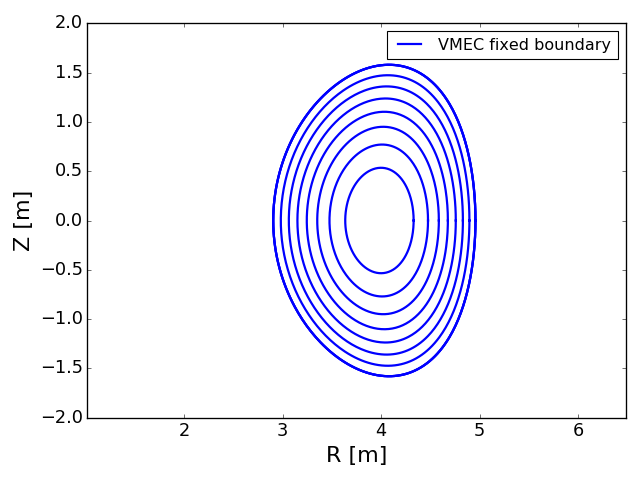

```python
for i in np.arange(0,129,16)-1:
    plot_vmec_surface('wout_SOLOVEV.nc',i,color='b', lbl=None)
plot_vmec_surface('wout_SOLOVEV.nc',color='b',lbl='VMEC fixed boundary');
plt.legend()
```

### BNORM results

**BNORM** is ran to calculate the normal component of plasma currents. The resolution is $Mpol=24$ and $Ntor=14$. We used **BNORM** to produce a uniformly expanded surface with a separation of 0.5m. Reading the Fourier coefficients and plot out the distribution of Bn_plasma.

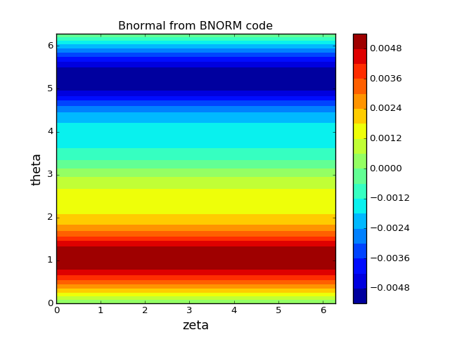

```python
plt.figure()
plt.contourf(tbn,zbn,bnorm, 18)
plt.xlabel('zeta', fontsize=16)
plt.ylabel('theta', fontsize=16)
plt.title('Bnormal from BNORM code')
plt.colorbar()
```

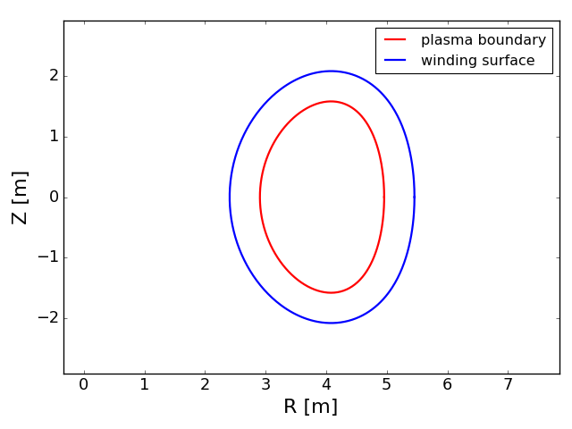

```
read 3 Fourier harmonics for plasma boundary and 725 for Bn distribution in plasma.boundary.
nfp: 1
Number of Fourier modes in coil surface from nescin file:          1201
```

```python
fig = plt.figure()
plot_plasma_boundary('plasma.boundary', color='r', lbl='plasma boundary');
plot_winding_surface('test.winding', color='b', lbl='winding surface');
plt.legend()
```

### NESCOIL results

Run **NESCOIL** with the input file *nescin.SOLOVEV* prepared by **BNORM**. Some resolution parameters are as below.

```
------ Spatial dimensions ----
nu, nv, nu1, nv1, npol, ntor, lasym_bn
         128  128  128  128    64          10 F

------ Fourier Dimensions ----
mf, nf, md, nd (max in surf and bnorm files)
          8   8        24          20
```

Here is part of the output.

```
Complexity =   1.13817350E+00
Time in Solver:     19.8     sec
----- Calling Surfcur_Diag -----
J Surf max, min, ave =   6.67491028E-02  3.14638915E-02  4.39897927E-02
Curv_R of J min, max =   1.12452252E+00  4.22091801E+00
Time in Surfcur_Diag:    0.149     sec
----- Calling Accuracy -----
Berr ave, max, var =   3.65157304E-05  7.60790295E-05  2.03785308E-05
Bmod ave, rms =   2.58046901E-01  3.68682330E-01
ACCURACY took     10.6     sec
ONE NESCOIL RUN took     30.6     sec
```

**NESCOIL** only writes the single-valued current potential. We can read in the Fourier coefficients and plot out the distribution of $\Phi_{SV}$. Of course, by adding the secular terms, $G$ & $I$, we could obtain the total current potential.

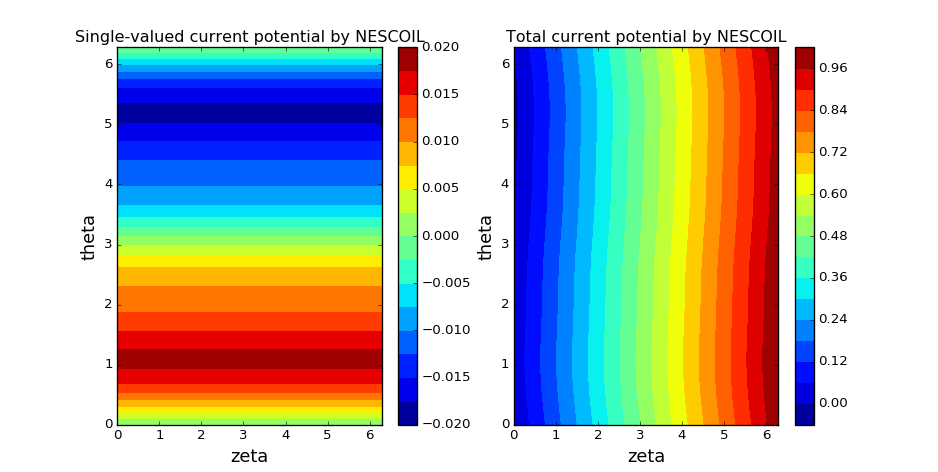

```python
plt.figure()
plt.subplot(121)
plt.contourf(zeta,theta,cp, 18)
plt.xlabel('zeta', fontsize=16)
plt.ylabel('theta', fontsize=16)
plt.title('Single-valued current potential by NESCOIL')
plt.colorbar()
######
plt.subplot(122)
plt.contourf(zeta,theta,tcp, 18)
plt.xlabel('zeta', fontsize=16)
plt.ylabel('theta', fontsize=16)
plt.title('Total current potential by NESCOIL')
plt.colorbar()
```

### REGCOIL results

Run **REGCOIL** with the following input file.

```
&regcoil_nml
  nlambda = 1
  lambda_min = 1e-15
  lambda_max = 1e-14

  ntheta_plasma = 128
  ntheta_coil   = 128
  nzeta_plasma  = 128
  nzeta_coil    = 128
  mpol_potential = 8
  ntor_potential = 8

  geometry_option_plasma = 2
  wout_filename = 'wout_SOLOVEV.nc'

  geometry_option_coil=2
  nescin_filename = 'test.winding'
  separation = 0.5

  load_bnorm=.t.
  bnorm_filename='bnorm.SOLOVEV'

  net_poloidal_current_Amperes = 0.0
  net_toroidal_current_Amperes = 0.0

  symmetry_option = 1

  save_level = 1
/
```

It is running without any regularization on current density and the same resolution with **NESCOIL**. Here is one part of the screen output.

```
 Solving system for lambda= 0.000E+00 (  1 of   1)
   Additions:    0.00000000      sec.
   DSYSV:    1.00000005E-03  sec.
   Diagnostics:    2.19999999E-02  sec.
   chi2_B: 8.831E-09,  chi2_K: 6.755E+12,  chi2_Laplace_Beltrami: 1.684E+11
   max(B_n): 1.130E-05,  max(K): 2.413E+05,  rms K: 1.537E+05
 REGCOIL complete. Total time=   19.229000091552734      sec.
```

Plot out the results.

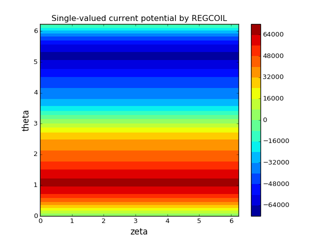

```python
reg_scp = plot_regcoil_potential('regcoil_out.test.nc',0,num_contours=18, total=False);
plt.title('Single-valued current potential by REGCOIL')
```

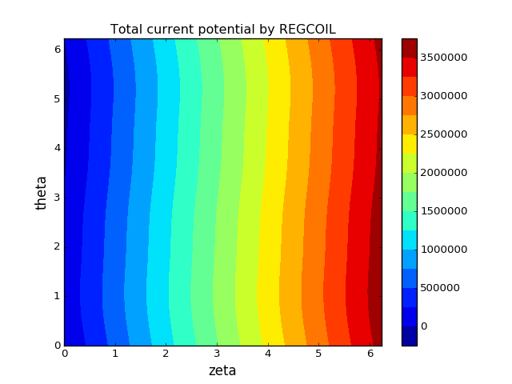

```python
reg_tcp = plot_regcoil_potential('regcoil_out.test.nc',0,num_contours=18, total=True);
plt.title('Total current potential by REGCOIL')
```

### Benchmark between NESCOIL and REGCOIL

We can now taking the conclusion we derive above, i.e. normalize **REGCOIL** results with a factor of $I_p/nfp = 3.6152$MA in this case. The numbers are consistent, to some precision.

[figure not shown]

```python
plt.figure()
plt.subplot(121)
plt.contourf(zeta,theta,reg_scp/fac-cp, 18)
plt.xlabel('zeta', fontsize=16)
plt.ylabel('theta', fontsize=16)
plt.title('Difference between NESCOIL and norm. REGCOIL (Phi_SV)')
plt.colorbar()

plt.subplot(122)
plt.contourf(zeta,theta,cp, 18)
plt.xlabel('zeta', fontsize=16)
plt.ylabel('theta', fontsize=16)
plt.title('Original NESCOIL results (Phi_SV)')
plt.colorbar()
```

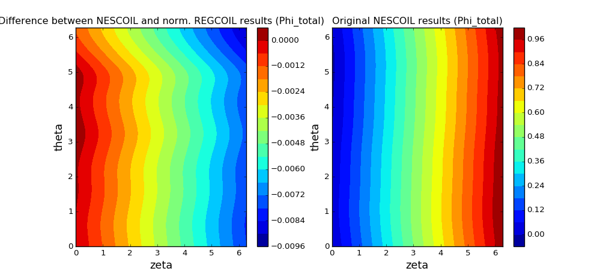

```python
plt.figure()
plt.subplot(121)
plt.contourf(zeta,theta,reg_tcp/fac-tcp, 18)
plt.xlabel('zeta', fontsize=16)
plt.ylabel('theta', fontsize=16)
plt.title('Difference between NESCOIL and norm. REGCOIL results (Phi_total)')
plt.colorbar()

plt.subplot(122)
plt.contourf(zeta,theta,tcp, 18)
plt.xlabel('zeta', fontsize=16)
plt.ylabel('theta', fontsize=16)
plt.title('Original NESCOIL results (Phi_total)')
plt.colorbar()
```

### Free-boundary VMEC results

We can now cut coils from the contours of total current potential. We assume there are 32 coils in total. The amount of current flowing in each coil is $I_p/N = 0.113$MA. Here is a picture of final coils (using cutCoilsFromREGCOIL, num_of_contours=32, no theta shift).

```
Read 32 coils in coils.test_regcoil.
read 3 Fourier harmonics for plasma boundary and 725 for Bn distribution in plasma.boundary.
```

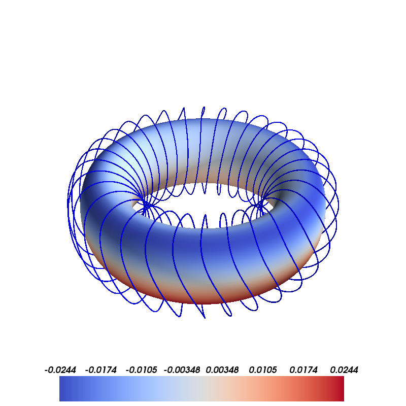

```python
## colors on plasma is the Bn produced by plasma currents
fig = mlab.figure(size=[800,800])
plot_coils(read_coils('coils.test_regcoil'));
plot_plasma_boundary('plasma.boundary', 'bnormal');
mlab.colorbar()
fig
```

A mgrid file is generated by this modular coils and then used in **VMEC** for free-boundary running. **Somehow, the sign of phiedge in VMEC has to be flipped.** Except that, the free-boundary **VMEC** results are consistent with fixed-boundary results, with surprisingly good precision.

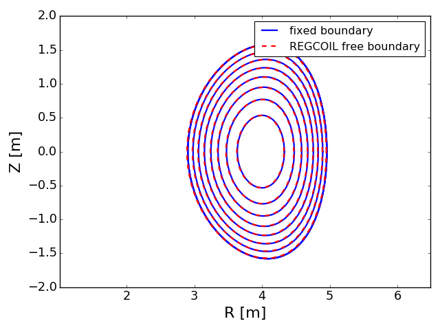

```python
for i in np.arange(0,129,16)-1:
    plot_vmec_surface('wout_SOLOVEV.nc',i,color='b', lbl=None)
    plot_vmec_surface('wout_regcoil_fb.nc',i,color='r', style='--',lbl=None)
plot_vmec_surface('wout_SOLOVEV.nc',color='b',lbl='fixed boundary');
plot_vmec_surface('wout_regcoil_fb.nc', color='r', style='--', lbl='REGCOIL free boundary');
plt.legend()
```

When using **FOCUS** to read the modular coils and diagnose the magnetic field, the surface integral of residual normal field is 1.15695E-03.

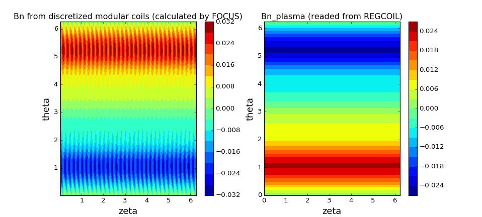

```python
half = 0.5
theta_focus = (np.arange(128) + half) * (2*np.pi)/128
zeta_focus = (np.arange(256) + half) * (2*np.pi)/256

plt.figure()
plt.subplot(121)
plt.contourf(zeta_focus, theta_focus, np.transpose(regcoil.Bn + regcoil.plas_Bn), 18)
plt.xlabel('zeta', fontsize=16)
plt.ylabel('theta', fontsize=16)
plt.title('Bn from discretized modular coils (calculated by FOCUS)')
plt.colorbar()

plt.subplot(122)
plt.contourf(zeta_regcoil, theta_regcoil, np.transpose(reg_Bn), 18)
plt.xlabel('zeta', fontsize=16)
plt.ylabel('theta', fontsize=16)
plt.title('Bn_plasma (readed from REGCOIL)')
plt.colorbar()
```

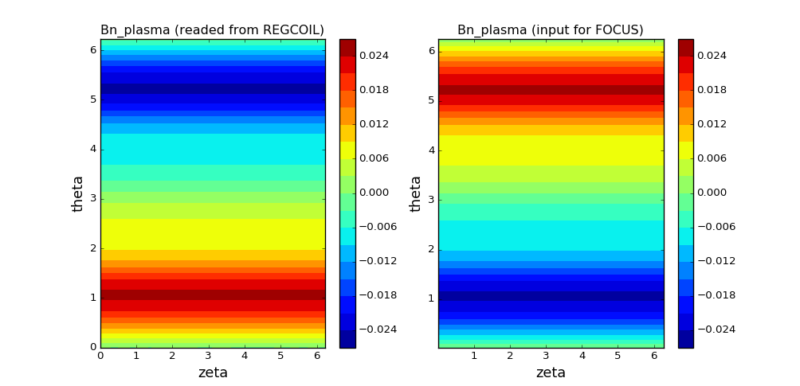

```python
f = netcdf.netcdf_file('regcoil_out.test.nc','r',mmap=False)
reg_Bn = f.variables['Bnormal_from_plasma_current'][()]
theta_regcoil = f.variables['theta_plasma'][()]
zeta_regcoil = f.variables['zeta_plasma'][()]
plt.figure()
plt.subplot(121)
plt.contourf(zeta_regcoil, theta_regcoil, np.transpose(reg_Bn), 18)
plt.xlabel('zeta', fontsize=16)
plt.ylabel('theta', fontsize=16)
plt.title('Bn_plasma (readed from REGCOIL)')
plt.colorbar()
plt.subplot(122)
plt.contourf(zeta_focus, theta_focus, np.transpose(regcoil.plas_Bn), 18)
plt.xlabel('zeta', fontsize=16)
plt.ylabel('theta', fontsize=16)
plt.title('Bn_plasma (input for FOCUS)')
plt.colorbar()
```

### FOCUS results

```python
from mayavi import mlab
mlab.init_notebook()
%matplotlib notebook
%run ~/python/scripts/coilpy.py
import seaborn as sns
sns.set(style="white", context="paper")
```

```
WARNING: Imported VTK version (8.1) does not match the one used
         to build the TVTK classes (6.3). This may cause problems.
         Please rebuild TVTK.

Notebook initialized with x3d backend.
```

```python
cd /p/focus/users/czhu/SPEC/test/SOLOVEV
```

```
/p/focus/users/czhu/SPEC/test/SOLOVEV
```

```python
vmec2focus('wout_solovev.nc', focus_file='solovev.boundary_noflip', bnorm_file='bnorm.solovev', flipsign=False)
vmec2focus('wout_solovev.nc', focus_file='solovev.boundary_flip', bnorm_file='bnorm.solovev', flipsign=True)
```

```
Total poloidal current needed is  3.61519089469759  MA.
Read  725  harmonics in BNORM file. M = 24 , N = 14
Finished write FOCUS input file at  solovev.boundary_noflip
Total poloidal current needed is  3.61519089469759  MA.
Read  725  harmonics in BNORM file. M = 24 , N = 14
Finished write FOCUS input file at  solovev.boundary_flip
```

```python
cd /p/focus/users/czhu/NCSX/c09r00/
```

```
/p/focus/users/czhu/NCSX/c09r00
```

```python
vmec2focus('wout_c09r00_fb.nc', focus_file='c09r00.boundary_noflip', bnorm_file='bnorm.c09r00_fb', flipsign=False)
vmec2focus('wout_c09r00_fb.nc', focus_file='c09r00.boundary_flip', bnorm_file='bnorm.c09r00_fb', flipsign=True)
```

```
Total poloidal current needed is  11.871007299188548  MA.
Read  725  harmonics in BNORM file. M = 24 , N = 14
Finished write FOCUS input file at  c09r00.boundary_noflip
Total poloidal current needed is  11.871007299188548  MA.
Read  725  harmonics in BNORM file. M = 24 , N = 14
Finished write FOCUS input file at  c09r00.boundary_flip
```

```python
3.61519089469759/32
```

```
0.11297471545929968
```

```python
modular = hdf5('focus_solovev_20200110_modular.h5')
```

```
Read  90  objects in <HDF5 file "focus_solovev_20200110_modular.h5" (mode r)>
FOCUS version : v0.9.00
```

```
Read 32 coils in solovev_20200110_modular.coils.
```

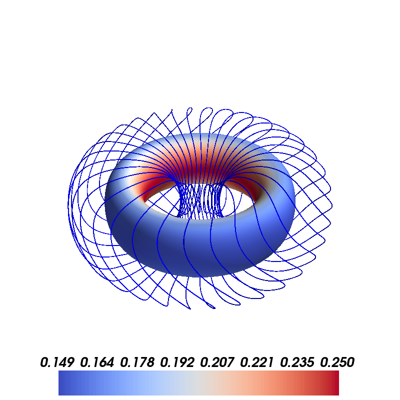

```python
fig = mlab.figure(size=[800,800])
plot_coils(read_coils('solovev_20200110_modular.coils'), currents=False);
plot_hdf5_surface(modular, 'Bmod');
mlab.colorbar()
fig
```

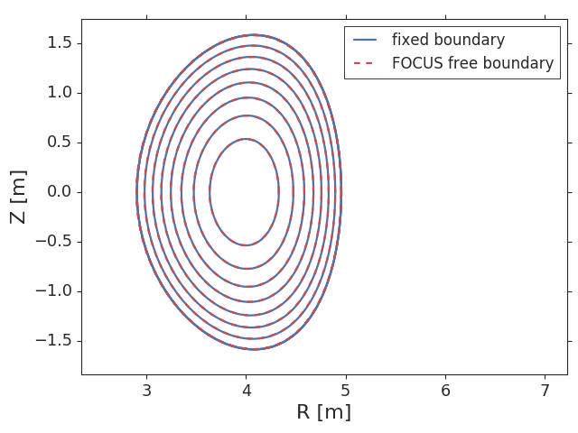

```python
for i in np.arange(0,129,16)-1:
    plot_vmec_surface('wout_solovev.nc',i,color='b', lbl=None)
    plot_vmec_surface('wout_solovev_20200110.nc',i,color='r', style='--',lbl=None)
plot_vmec_surface('wout_solovev.nc',color='b',lbl='fixed boundary');
plot_vmec_surface('wout_solovev_20200110.nc', color='r', style='--', lbl='FOCUS free boundary');
plt.legend(fontsize=15)
```

## Appendix B: A simple verification of FOCUS

This is a small demo showing that **FOCUS** is calculating magnetic field correctly. There is a circular plasma boundary with $R_p=4.0$ m, $r_p=1.0$ m. Assuming there are 128 circular TF coils ($r_c = 2.0$ m) with $I_c = 0.1$MA. The toroidal magnetic field can be computed by Ampere's Law, $B_t = \frac{\mu_0 I}{2\pi r}$. In this case, $I = 128*Ic=1.28\times 10^7$A and $B_t = 2.56/r$.

The toroidal flux should be $\Psi_t = \int_ 3^5 2*\sqrt {1 - (x - 4)^2} \frac{2.56}{x}\, dx = -2.043057082564284$ Wb. It is negative because the coil current flows in the counter-clockwise direction, which means the total current is flowing in negative Z direction and creates a toroidal field in the clock-wise direction.

The magnetic field calculated by FOCUS shows good consistency with the analytical values. The calculated toroidal flux is $-2.043584789045241$ Wb, which is also close to the analytical value up to numerical discretization erros.

```
Read  83  objects in <HDF5 file "focus_test.h5" (mode r)>
FOCUS version : v0.6.02
Read 128 coils in ../test.coils.
```

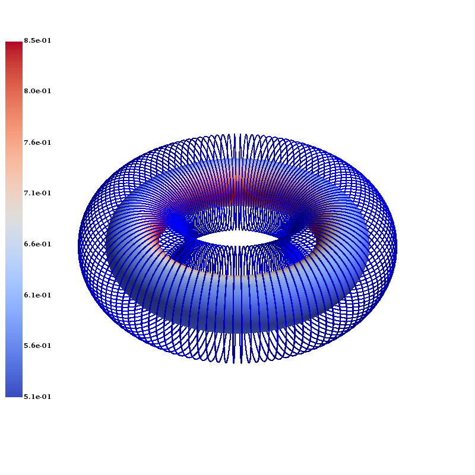

```python
test = hdf5('../focus_test.h5')
fig = mlab.figure(size=[800,800])
plot_coils(read_coils('../test.coils'));
plot_hdf5_surface(test, 'Bmod')
mlab.colorbar()
fig
```

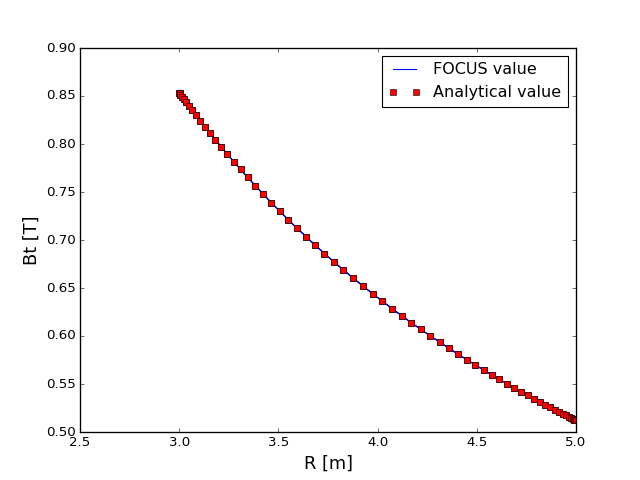

```python
plt.figure()
Bt = np.sqrt(test.Bx*test.Bx + test.By*test.By)
r = np.sqrt(test.xsurf*test.xsurf + test.ysurf*test.ysurf)
plt.plot(r[0,:], Bt[0,:], label='FOCUS value')
plt.plot(r[0,:], 2.56/r[0,:], marker='s', color='r', linestyle='none', label='Analytical value')
plt.ylabel('Bt [T]', fontsize=16)
plt.xlabel('R [m]', fontsize=16)
plt.legend()
```